# Entrega 1. Modelos de regresión lineal

### 9. Analice el modelo. Determine si hay multicolinealidad entre las variables, y cuáles son las que aportan al modelo. Haga un análisis de correlación de las características del modelo y especifique si el modelo se adapta bien a los datos. Explique si hay sobreajuste (overfitting) o no. En caso de existir sobreajuste, haga otro modelo que lo corrija.

Podemos ver que nuestro modelo lastimosamente si esta sobreajustado ya que su R ajustado es de 0.97 y de 1 si realizamos stepwise . Ademas que podemos ver que al predecir con los test no lo esta haciendo de la manera correcta aun cuando normalicemos , y apliquemos tecnicas para reducir datos atipicos.

- Lo primero que vamos a hacer es usar la matriz de correlacion.

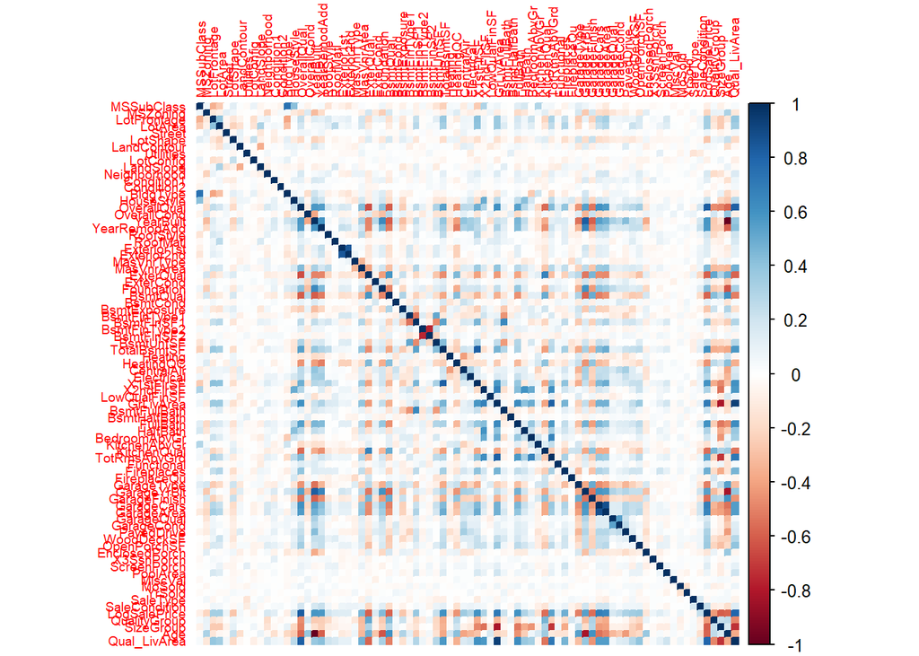

```r
library(car)


cor_matrix <- cor(train[, -which(names(train) == "SalePrice")], use = "pairwise.complete.obs")


library(corrplot)
corrplot(cor_matrix, method = "color", tl.cex = 0.6, tl.srt = 90)
```

Ahora conocemos la correlacion alta.

```r
high_cor <- which(abs(cor_matrix) > 0.8, arr.ind = TRUE)


high_cor <- high_cor[high_cor[,1] != high_cor[,2], ]
print(high_cor)
```

```
##              row col
## LogSalePrice  76  16
## Qual_LivArea  80  16
## GarageYrBlt   58  18
## Age           79  18
## Exterior2nd   23  22
## Exterior1st   22  23
## X1stFlrSF     42  37
## TotalBsmtSF   37  42
## TotRmsAbvGrd  53  45
## SizeGroup     78  45
## Qual_LivArea  80  45
## GrLivArea     45  53
## YearBuilt     18  58
## Age           79  58
## GarageArea    61  60
## GarageCars    60  61
## OverallQual   16  76
## GrLivArea     45  78
## YearBuilt     18  79
## GarageYrBlt   58  79
## OverallQual   16  80
## GrLivArea     45  80
```

Como podemos ver estas variables estan causando alta coinealidad de hecho podemos graficarlas con una matriz de correlacion

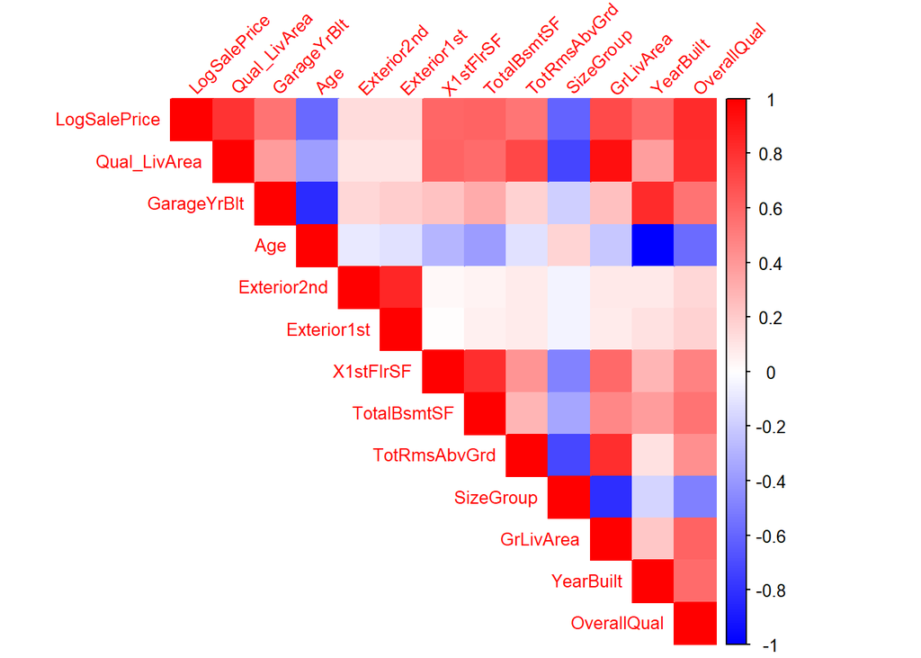

```r
top_vars <- c("LogSalePrice", "Qual_LivArea", "GarageYrBlt", "Age", "Exterior2nd",
              "Exterior1st", "X1stFlrSF", "TotalBsmtSF", "TotRmsAbvGrd", "SizeGroup",
              "GrLivArea", "YearBuilt", "OverallQual")


filtered_train <- train[, top_vars]


cor_matrix_filtered <- cor(filtered_train, use = "pairwise.complete.obs")


library(corrplot)
corrplot(cor_matrix_filtered, method = "color", type = "upper",
         tl.cex = 0.8, tl.srt = 45,
         col = colorRampPalette(c("blue", "white", "red"))(200),
         cl.cex = 0.8)
```

Pero antes de eliminar variables multicolineales vamos a hacer una cosa. Utilizaremos Ridge y regularicemos para ver que tan bien rinden.

```r
x_train <- model.matrix(SalePrice~., data = train)
y_train <- train$SalePrice

x_test <- model.matrix(SalePrice~., data = test_d)
y_test <- test_d$SalePrice
```

```r
# Asegurar que ambos tengan las mismas filas



set.seed(123)  # Para reproducibilidad
indices <- sample(1:nrow(x_train), 1064)  # Seleccionar 1064 índices aleatorios

x_train <- x_train[indices, ]  # Filtrar filas de x_train
y_train <- y_train[indices]  # Filtrar elementos de y_train



# Variables en train y test
vars_train <- colnames(x_train)
vars_test <- colnames(x_test)

# Variables que están en test pero no en train
extra_vars_in_test <- setdiff(vars_test, vars_train)
print(extra_vars_in_test)
```

```
## character(0)
```

```r
x_test <- x_test[, colnames(x_train)]
```

Se hace la regularización con un 100 números de λ porque no sabemos cual es el lambda adecuado.

```r
library(tidyverse)
library(glmnet)
modelo3 <- glmnet(
            x           = x_train,
            y           = y_train,
            alpha       = 0,
            nlambda     = 100,
            standardize = TRUE
          )

regularizacion <- modelo3$beta %>%
                  as.matrix() %>%
                  t() %>%
                  as_tibble() %>%
                  mutate(lambda = modelo3$lambda)

regularizacion <- regularizacion %>%
                   pivot_longer(
                     cols = !lambda,
                     names_to = "predictor",
                     values_to = "coeficientes"
                   )
```

Ahora graficamos loos coeficientes

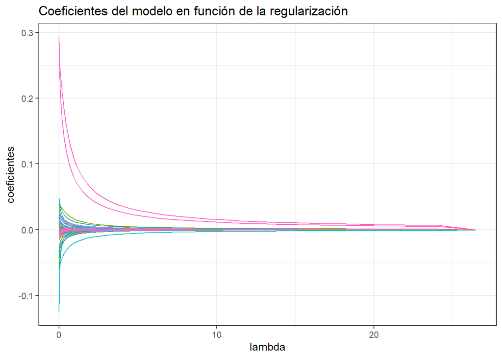

```r
 regularizacion %>%
  ggplot(aes(x = lambda, y = coeficientes, color = predictor)) +
  geom_line() +
  labs(title = "Coeficientes del modelo en función de la regularización") +
  theme_bw() +
  theme(legend.position = "none")
```

#### Analisis

Ahora obtendremos el valor optimo de este con la validacion cruzada

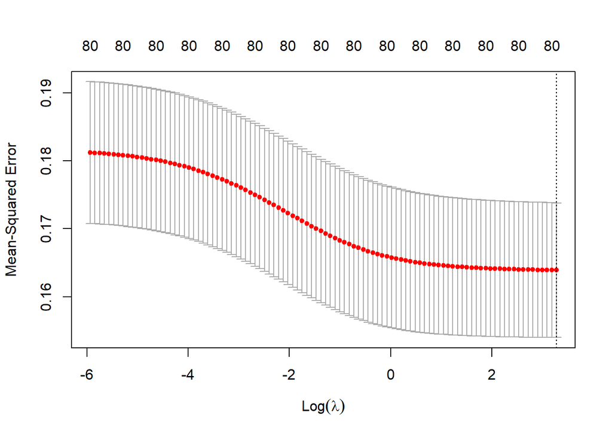

```r
cv_error <- cv.glmnet(
              x      = x_train,
              y      = y_train,
              alpha  = 0,
              nfolds = 10,
              type.measure = "mse",
              standardize  = TRUE
           )

plot(cv_error)
```

```r
lambda_opt <- cv_error$lambda.min
print(lambda_opt)
```

```
## [1] 26.461
```

Vemos que el valor es de 26.461 asi que con estos nuevos datos vamos a entrenar nuestro modelo

```r
modelo3 <- glmnet(
            x           = x_train,
            y           = y_train,
            alpha       = 0,
            lambda      = cv_error$lambda.1se,
            standardize = TRUE
          )
```

Ahora vemos los predictores y sus coeficientes. Ridge no elimina variables

```r
coef(modelo3)
```

```
## 82 x 1 sparse Matrix of class "dgCMatrix"
##                          s0
## (Intercept)    1.207382e+01
## (Intercept)    .
## MSSubClass     4.515121e-06
## MSZoning       4.179668e-04
## LotFrontage   -5.409408e-06
## LotArea        3.073674e-09
## Street         4.525338e-03
## LotShape      -1.471795e-04
## LandContour    1.314613e-04
## Utilities      6.075601e-03
## LotConfig     -6.331918e-05
## LandSlope      2.620790e-04
## Neighborhood  -2.220386e-05
## Condition1    -1.534585e-04
## Condition2     8.772832e-04
## BldgType       7.211048e-05
## HouseStyle     1.121914e-04
## OverallQual    6.834960e-05
## OverallCond    1.416514e-04
## YearBuilt      2.397077e-06
## YearRemodAdd   7.260293e-06
## RoofStyle     -5.690055e-05
## RoofMatl      -2.441608e-04
## Exterior1st   -1.993581e-05
## Exterior2nd   -3.912711e-05
## MasVnrType     1.665318e-04
## MasVnrArea     1.900151e-06
## ExterQual     -4.125442e-04
## ExterCond     -1.741876e-04
## Foundation     1.827276e-04
## BsmtQual      -2.072784e-05
## BsmtCond      -1.470414e-04
## BsmtExposure  -1.580206e-04
## BsmtFinType1  -1.555944e-04
## BsmtFinSF1     5.104843e-07
## BsmtFinType2   2.911629e-04
## BsmtFinSF2    -5.394616e-07
## BsmtUnfSF     -5.742780e-07
```

[output cut: 29 more lines]

```
## OpenPorchSF   -3.010105e-06
## EnclosedPorch  3.805465e-06
## X3SsnPorch     3.057135e-06
## ScreenPorch    5.792205e-06
## PoolArea      -2.027554e-06
## MiscVal       -2.470766e-07
## MoSold        -1.370612e-04
## YrSold        -4.477718e-05
## SaleType      -6.633982e-05
## SaleCondition  6.043839e-05
## LogSalePrice   1.623581e-04
## QualityGroup  -1.117004e-04
## SizeGroup     -1.041487e-04
## Age           -2.482621e-06
## Qual_LivArea   3.621051e-08
```

```r
predicciones_train_modelo3<- predict(modelo3, newx = x_train)


predicciones_test_modelo3 <- predict(modelo3, newx = x_test)



y_test <- y_test[1:nrow(x_test)]

# MSE de test
test_mse_ridge_modelo3 <- mean((predicciones_test_modelo3 - y_test)^2)

# MSE de entrenamiento
training_mse_ridge_modelo3 <- mean((predicciones_train_modelo3 - y_train)^2)


print(test_mse_ridge_modelo3)
```

```
## [1] 0.1436333
```

```r
print(training_mse_ridge_modelo3)
```

```
## [1] 0.1631888
```

#### Analisis

```r
predicciones_train_modelo3 <- predict(modelo3, newx = x_train)
predicciones_test_modelo3 <- predict(modelo3, newx = x_test)


y_test <- y_test[1:nrow(x_test)]

# Calcular MSE
test_mse_ridge_modelo3 <- mean((predicciones_test_modelo3 - y_test)^2)
training_mse_ridge_modelo3 <- mean((predicciones_train_modelo3 - y_train)^2)

# Calcular residuos
residuos_train <- y_train - predicciones_train_modelo3
residuos_test <- y_test - predicciones_test_modelo3


print(test_mse_ridge_modelo3)
```

```
## [1] 0.1436333
```

```r
print(training_mse_ridge_modelo3)
```

```
## [1] 0.1631888
```

```r
summary(residuos_train)
```

```
##        s0
##  Min.   :-1.5540
##  1st Qu.:-0.2500
##  Median :-0.0226
##  Mean   : 0.0000
##  3rd Qu.: 0.2452
##  Max.   : 1.5055
```

```r
summary(residuos_test)
```

```
##        s0
##  Min.   :-1.554982
##  1st Qu.:-0.251913
##  Median :-0.023444
##  Mean   :-0.006019
##  3rd Qu.: 0.232994
##  Max.   : 0.967486
```

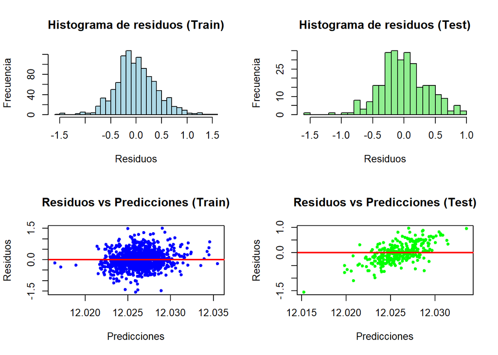

```r
par(mfrow=c(2,2))


hist(residuos_train, main="Histograma de residuos (Train)",
     col="lightblue", breaks=30, xlab="Residuos", ylab="Frecuencia")


hist(residuos_test, main="Histograma de residuos (Test)",
     col="lightgreen", breaks=30, xlab="Residuos", ylab="Frecuencia")



plot(predicciones_train_modelo3, residuos_train,
     main="Residuos vs Predicciones (Train)",
     xlab="Predicciones", ylab="Residuos", pch=20, col="blue")
abline(h=0, col="red", lwd=2)


plot(predicciones_test_modelo3, residuos_test,
     main="Residuos vs Predicciones (Test)",
     xlab="Predicciones", ylab="Residuos", pch=20, col="green")
abline(h=0, col="red", lwd=2)
```

```r
# Resetear layout
par(mfrow=c(1,1))
```

### 10. Si tiene multicolinealidad o sobreajuste, haga un modelo con las variables que sean mejores predictoras del precio de las casas. Determine la calidad del modelo realizando un análisis de los residuos. Muéstrelo gráficamente.

Viendo en stepwise y al normalizar si hay sobreajuste asi que vamos a realizar Lazz y vamos a eliminar aquellas que sean peores predictoras o que no estan aportando a la prediccion de resultados.

Para lazoo necesitaremos alpha

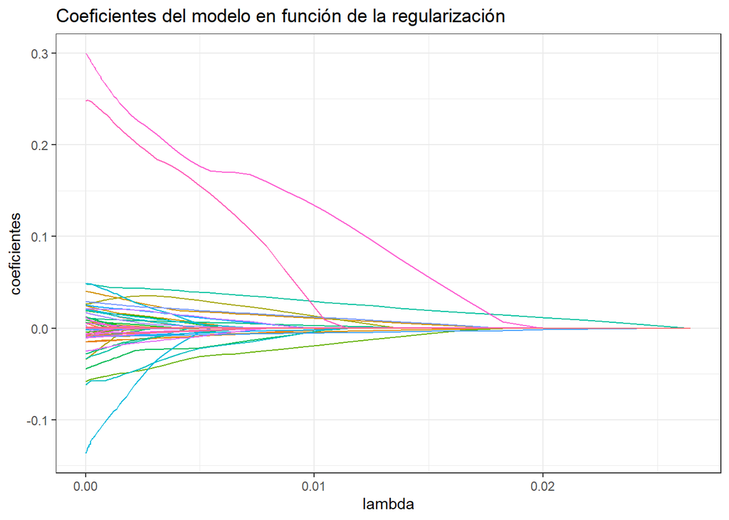

```r
modelo4 <- glmnet(
            x           = x_train,
            y           = y_train,
            alpha       = 1,
            nlambda     = 100,
            standardize = TRUE
          )

regularizacion <- modelo4$beta %>%
                  as.matrix() %>%
                  t() %>%
                  as_tibble() %>%
                  mutate(lambda = modelo4$lambda)

regularizacion <- regularizacion %>%
                   pivot_longer(
                     cols = !lambda,
                     names_to = "predictor",
                     values_to = "coeficientes"
                   )

regularizacion %>%
  ggplot(aes(x = lambda, y = coeficientes, color = predictor)) +
  geom_line() +
  labs(title = "Coeficientes del modelo en función de la regularización") +
  theme_bw() +
  theme(legend.position = "none")
```

#### Analisis

Este grafico indica lo mismo que con Ridge solo que vemos que en muy pocos valores de lambda estamos viendo que los coeficientes bajen abruptamente .

Ahora veamos el mejor valor de lambda con validacion cruzada

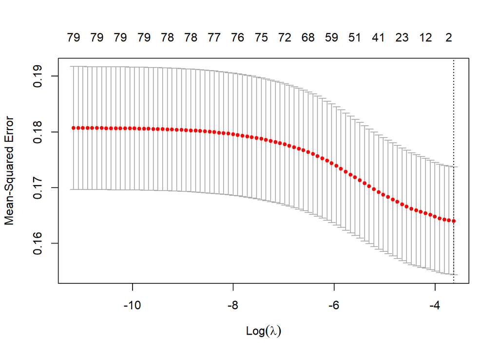

```r
cv_error <- cv.glmnet(
              x      = x_train,
              y      = y_train,
              alpha  = 1,
              nfolds = 10,
              type.measure = "mse",
              standardize  = TRUE
           )

plot(cv_error)
```

```r
lambda_opt2 <- cv_error$lambda.min
print(lambda_opt)
```

```
## [1] 26.461
```

#### Analisis

```r
modelo4 <- glmnet(
            x           = x_train,
            y           = y_train,
            alpha       = 1,
            lambda      = cv_error$lambda.1se,
            standardize = TRUE
          )
coef(modelo4)
```

```
## 82 x 1 sparse Matrix of class "dgCMatrix"
##                     s0
## (Intercept)   12.02623
## (Intercept)    0.00000
## MSSubClass     .
## MSZoning       .
## LotFrontage    .
## LotArea        .
## Street         .
## LotShape       .
## LandContour    .
## Utilities      .
## LotConfig      .
## LandSlope      .
## Neighborhood   .
## Condition1     .
## Condition2     .
## BldgType       .
## HouseStyle     .
## OverallQual    .
## OverallCond    .
## YearBuilt      .
## YearRemodAdd   .
## RoofStyle      .
## RoofMatl       .
## Exterior1st    .
## Exterior2nd    .
## MasVnrType     .
## MasVnrArea     .
## ExterQual      .
## ExterCond      .
## Foundation     .
## BsmtQual       .
## BsmtCond       .
## BsmtExposure   .
## BsmtFinType1   .
## BsmtFinSF1     .
## BsmtFinType2   .
## BsmtFinSF2     .
## BsmtUnfSF      .
```

[output cut: 29 more lines]

```
## OpenPorchSF    .
## EnclosedPorch  .
## X3SsnPorch     .
## ScreenPorch    .
## PoolArea       .
## MiscVal        .
## MoSold         .
## YrSold         .
## SaleType       .
## SaleCondition  .
## LogSalePrice   .
## QualityGroup   .
## SizeGroup      .
## Age            .
## Qual_LivArea   .
```

Al final solo nos quedamos con 2 esto es normal para este tipo de seleccion de variables

```r
predicciones_train_modelo4<- predict(modelo4, newx = x_train)


predicciones_test_modelo4 <- predict(modelo4, newx = x_test)

# MSE de test
test_mse_lasso_modelo4 <- mean((predicciones_test_modelo4 - y_test)^2)

# MSE de entrenamiento
training_mse_lasso_modelo4 <- mean((predicciones_train_modelo4 - y_train)^2)

print(test_mse_lasso_modelo4 )
```

```
## [1] 0.1447764
```

```r
print(training_mse_lasso_modelo4 )
```

```
## [1] 0.1634659
```

#### Analisis

Podemos ver que realmente no cambio nada de los valores que se detectaron al inicio , asi que vamos ahora a mostrarlos en un grafico que demuestre la diferencia entre los modelos.

```r
# Calcular residuos
residuos_train <- y_train - predicciones_train_modelo4
residuos_test <- y_test - predicciones_test_modelo4


print(test_mse_ridge_modelo3)
```

```
## [1] 0.1436333
```

```r
print(training_mse_ridge_modelo3)
```

```
## [1] 0.1631888
```

```r
summary(residuos_train)
```

```
##        s0
##  Min.   :-1.5543
##  1st Qu.:-0.2509
##  Median :-0.0232
##  Mean   : 0.0000
##  3rd Qu.: 0.2475
##  Max.   : 1.5082
```

```r
summary(residuos_test)
```

```
##        s0
##  Min.   :-1.565992
##  1st Qu.:-0.252871
##  Median :-0.024729
##  Mean   :-0.006394
##  3rd Qu.: 0.233368
##  Max.   : 0.968296
```

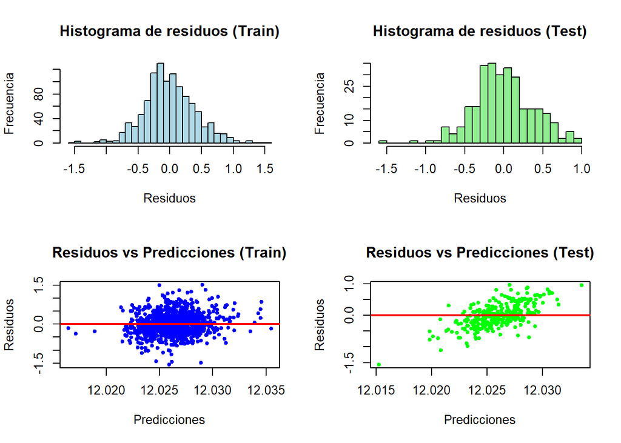

```r
par(mfrow=c(2,2))


hist(residuos_train, main="Histograma de residuos (Train)",
     col="lightblue", breaks=30, xlab="Residuos", ylab="Frecuencia")


hist(residuos_test, main="Histograma de residuos (Test)",
     col="lightgreen", breaks=30, xlab="Residuos", ylab="Frecuencia")



plot(predicciones_train_modelo3, residuos_train,
     main="Residuos vs Predicciones (Train)",
     xlab="Predicciones", ylab="Residuos", pch=20, col="blue")
abline(h=0, col="red", lwd=2)


plot(predicciones_test_modelo3, residuos_test,
     main="Residuos vs Predicciones (Test)",
     xlab="Predicciones", ylab="Residuos", pch=20, col="green")
abline(h=0, col="red", lwd=2)
```

```r
# Resetear layout
par(mfrow=c(1,1))
```

#### Analisis

Viendo los residuos vemos el mismo patron al que utilizar Ridge lo que indica que ambos modelos son casi iguales en eficiencia. De hecho vemos que la dispersion y el histograma son exactos por lo que no es necesario llevar a cabo otros modelos.

### 11. Utilice cada modelo con el conjunto de prueba y determine la eficiencia del algoritmo para predecir el precio de las casas. ¿Qué tan bien lo hizo?¿Qué medidas usó para determinar la calidad de la predicción?

Como se vio anteriormente se realizo una prediccion con cada uno de los modelos tuvo un error medio cuadrado igual. Esta fue la metrica que se utilizo debido a que el MSE permite evaluar la precisión del modelo midiendo la diferencia cuadrática media entre los valores predichos y los valores reales.

El MSE es una métrica útil porque penaliza los errores grandes de manera más severa que los pequeños, lo que ayuda a identificar modelos con predicciones más precisas. Un MSE más bajo indica un mejor ajuste del modelo a los datos de entrenamiento y prueba.

En retroalimentacion se puede ver que el que mejor desepeño tuvo de los 2 fue el mismo a pesar de utilizar 2 enfoques diferenetes.

### 12. Discuta sobre la efectividad de los modelos. ¿Cuál lo hizo mejor? ¿Cuál es el mejor modelo para predecir el precio de las casas? Haga los gráficos que crea que le pueden ayudar en la discusión.

Para poder observar como fue este comportamiento vamos a ver utilizando una grafica de barras para todos los modelos

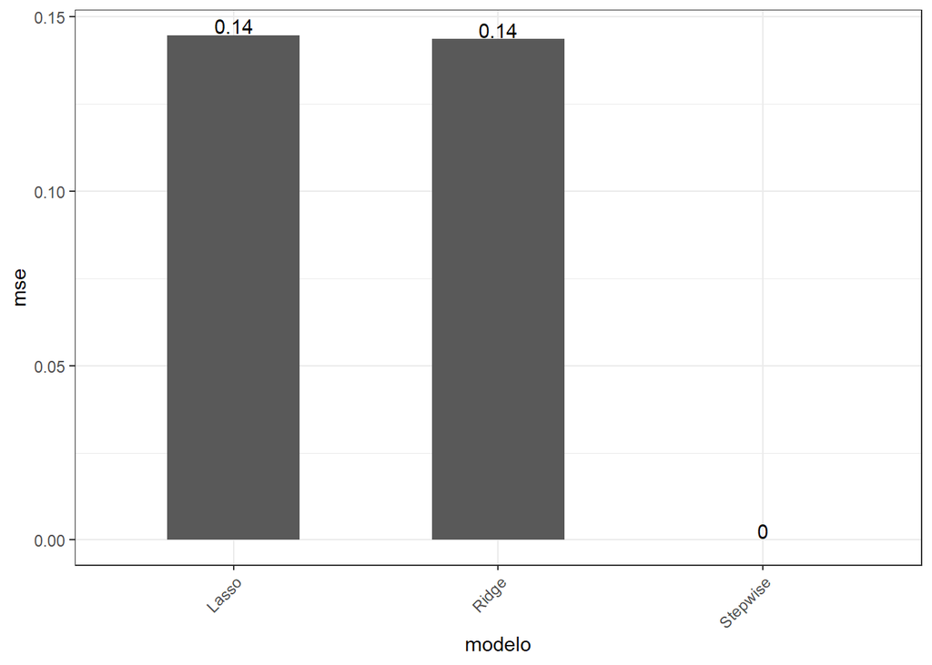

```r
df_comparacion <- data.frame(
                    modelo = c("Stepwise", "Ridge", "Lasso"),
                    mse    = c(test_mse_stepwise, test_mse_ridge_modelo3,
                                test_mse_lasso_modelo4)
)

ggplot(data = df_comparacion, aes(x = modelo, y = mse)) +
  geom_col(width = 0.5) +
  geom_text(aes(label = round(mse, 2)), vjust = -0.1) +
  theme_bw() +
  theme(axis.text.x = element_text(angle = 45, hjust = 1))
```

#### Analisis

Solo que utilizaremos Ridge en este caso dado los 3 modelos. Porque no utilizamos stepwise, esto se debe a que estamos hablando cuando tenemos el mse es muy bajo osea tendiendo a 0 tenemos un sobreajuste, esto ya lo habiamos discutido y de hecho con los residuos , y como queremos seguir conservando los resultados mas posibles entonces Ridge va a ser el que vamos a elegir en ves de Lasso, ya que Lasso elimino una gran parte de las variables solo dejando 2 .

En la siguiente gráfica vemos como quedarían las predicciones de acuerdo con los valores originales.

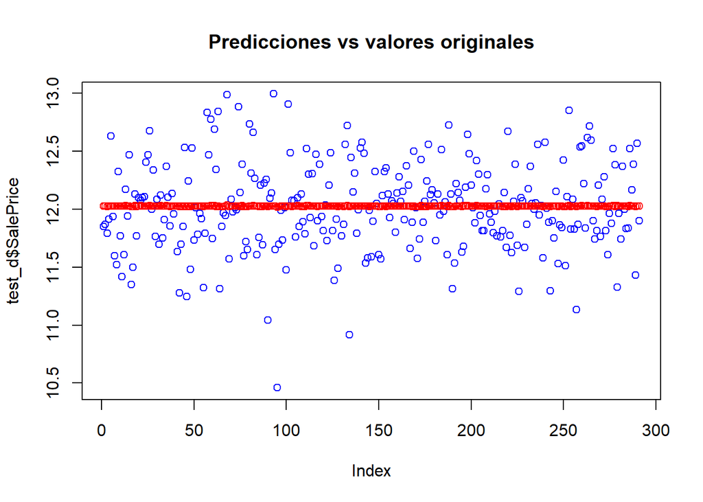

```r
plot(test_d$SalePrice,col="blue", main="Predicciones vs valores originales")
points(predicciones_test_modelo3, col="red")
legend(30,45,legend=c("original", "prediccion"),col=c("blue", "red"),pch=1, cex=0.8)
```

### Conclusiones

Como conclusiones podemos ver que el modelo multilineal elegiremos el dado por Ridge debido a que guarda la mayor parte de las variables y no reduce la dimensionalidad. En cambio Lasso elimina casi todas , y Stepwise es demasiado ajustado por lo que no permite generalizacion.

Conclusiones del Análisis de Clustering

1️. Interpretación General del Clustering

Cluster 1 (Rojo - Casas de Bajo Precio)

- Baja calidad de construcción (OverallQual bajo).
- Tamaño reducido en área habitable (GrLivArea pequeño) y sótano (TotalBsmtSF pequeño).
- Garaje pequeño o inexistente (GarageCars cercano a 0 o 1).
- Ubicadas en vecindarios de menor costo.
- Presentan los precios más bajos, lo que indica que su valor es más estable y menos dependiente de otros factores.

Cluster 2 (Azul - Casas de Precio Medio)

- Calidad media a alta (OverallQual entre 5 y 7).
- Tamaño intermedio con áreas habitables y sótanos de tamaño moderado.
- Garaje con espacio para 1 o 2 autos.
- Representan la mayoría del dataset, lo que sugiere que es el segmento más común en el mercado.
- Precio en el rango medio con variabilidad en función de la ubicación y otros factores.